# Analysis Document

Wentao Li, Hongyan Zheng

7/4/2021

## Overview and Motivation:

Throughout history, humans often struggle to find the solution to extend their mortality or even immortality. From inventing elixirs to offering sacrifices, yet we have seldom heard of those who have achieved this goal, yet various cultures across the globe have attempted it. Advancing into the 21st century, when many viral and bacterial diseases are preventable and infant mortality rate has dropped drastically, we pursue the question again, “what is the secret to longevity? Is happiness the key?”. Moreover, Nordic countries have consistently claimed the top seats in the World Happiness Report while maintaining a unique social welfare program. In this study, we hope to explore the reason, the variable with the highest impact, on Happiness.

In the following report, we have analyzed three important datasets, “The World Happiness Report” powered by data from Gallup World Poll, “Global Life Expectancy” collected from ourworldindata.org, and a dataset containing various countries and their respective continents via datahub.io, to discover the relationships between Global Life Expectancy and Global Happiness (represented by the Life Ladder Rank) and its various subsequent economic and social factors. We have discovered these relationships through combining datasets and cleaning the data, selecting specific response variables, finding significant explanatory variables, utilizing graphs to show the relationship between response and all explanatory variables, checking model assumptions and model building and showing the influence of significant explanatory variables vs. the response variable.

## Related Work:

*https://pubmed.ncbi.nlm.nih.gov/31451635/*

This study was inspired by “Optimism is associated with exceptional longevity in 2 epidemiologic cohorts of men and women”, a study conducted by numerous researchers such as Lewina O Lee, Peter James, Emily S. Zevon, etc. This research tested whether higher optimism was associated with longer life span and greater likelihood of exceptional longevity. The researchers analyzed data from two large population studies: the Nurses’ Health Study of 70,000 women, and the Veterans Affairs Normative Aging Study of 1,400 men. It also analyzed Happiness through the Life Orientation Test from the Nurses’ Health Study and the Optimism-Pessimism Scale from the Normative Aging study. The researchers found that for both men and women, higher levels of optimism were associated with a longer life span. This study inspired us as the results had shown that optimism did have a relationship with longevity. Therefore, we hoped to expand the study from optimism to general Happiness and the focus from only the United States to a more global perspective. After reading the study, we hoped to explore whether Happiness, in our study represented by the Life Ladder rank, is related to life expectancy.

## Initial Questions:

The study attempts to find the relationship between Life Expectancy and Happiness through exploring the following questions: “Are all Social and Economic variables such as GDP, Social Support, Freedom of Choice, Healthy Life Expectancy at birth, Generosity, Perceptions of corruption, Positive affect, and Negative affect related to Life Expectancy?”, “What is the relationship between Geography (continent) and Life Expectancy?”, “What is the relationship between Geography (continent) and Happiness?”, “Do happy people live longer? If so, which variable affects both life expectancy and Life Ladder rank the most?”, and finally “Does a change in life expectancy reflect a similar change in Happiness?”.

In its initial stages, the study also hoped to explore the relationship between COVID-19 cases across the world and each country’s socio-economic variables as well as global happiness. However, due to COVID-19 being a very recent event, and its long-lasting socio-economic impacts, it was decided after consideration to exclude these questions and the datasets all together, and instead focusing on further exploring the relationship between Life Expectancy and Happiness. This allowed us to explore the last two questions, and further examine how both the socio-economic variables and happiness impact life expectancy.

In the final stages of the project, we began to brainstorm additional questions for the project or future research and exploration. We planned to utilize predicting modelling and only a section of both given datasets to predict the relationship between life expectancy and happiness in the future. Therefore, we established the following question: “Knowing both the Happiness scores and Life Expectancy of all five continents from 2010 to 2019, how will Happiness and Life Expectancy change in 2020.” We believed this was an important question because we know that COVID-19 would create a global impact throughout 2020 and cause drastic changes. However, in the case that this event was miraculously avoided through early social distancing, quarantining and various other protective measures, would the relationship between Geography, Life Expectancy and Happiness still remain the same? However, we failed to pursue this question due to time constraints, but hope to pursue this question in a follow up study.

## Data:

We used the following packages for our analysis:

```r
library(readr)
library(tidyverse)
library(ggrepel)
library(tidyr)
library(tidymodels)
```

```r
lifeExpectancy_world <- read_csv("./data/lifeExpectancy_world.csv")
world_happiness_report <- read_csv("./data/world-happiness-report.csv")
continent_country_tag <- read.csv("./data/country-and-continent-codes-list-csv_csv.csv")
```

Here, we imported 3 csv files and stored them with respective names. Two of them are sourced from kaggle, and the other is datahub.io

```r
continent_country_tag <- continent_country_tag %>% rename("Code" = Three_Letter_Country_Code)
data <- lifeExpectancy_world %>%
  rename("Country name" = Entity) %>%
  pivot_longer(3:72, names_to = "year", values_to = "Expectancy") %>%
  mutate(year = as.numeric(year)) %>%
  filter(year >= 2008) %>%
  left_join(world_happiness_report) %>%
  left_join(continent_country_tag, by = "Code") %>%
  na.omit()

glimpse(data)
```

```
## Rows: 1,355
## Columns: 18
## $ `Country name`                     <chr> "Afghanistan", "Afghanistan", "Afgh~
## $ Code                               <chr> "AFG", "AFG", "AFG", "AFG", "AFG", ~
## $ year                               <dbl> 2008, 2009, 2010, 2011, 2012, 2013,~
## $ Expectancy                         <dbl> 59.930, 60.484, 61.028, 61.553, 62.~
## $ `Life Ladder`                      <dbl> 3.724, 4.402, 4.758, 3.832, 3.783, ~
## $ `Log GDP per capita`               <dbl> 7.370, 7.540, 7.647, 7.620, 7.705, ~
## $ `Social support`                   <dbl> 0.451, 0.552, 0.539, 0.521, 0.521, ~
## $ `Healthy life expectancy at birth` <dbl> 50.80, 51.20, 51.60, 51.92, 52.24, ~
## $ `Freedom to make life choices`     <dbl> 0.718, 0.679, 0.600, 0.496, 0.531, ~
## $ Generosity                         <dbl> 0.168, 0.190, 0.121, 0.162, 0.236, ~
## $ `Perceptions of corruption`        <dbl> 0.882, 0.850, 0.707, 0.731, 0.776, ~
## $ `Positive affect`                  <dbl> 0.518, 0.584, 0.618, 0.611, 0.710, ~
## $ `Negative affect`                  <dbl> 0.258, 0.237, 0.275, 0.267, 0.268, ~
## $ Continent_Name                     <chr> "Asia", "Asia", "Asia", "Asia", "As~
## $ Continent_Code                     <chr> "AS", "AS", "AS", "AS", "AS", "AS",~
## $ Country_Name                       <chr> "Afghanistan, Islamic Republic of",~
## $ Two_Letter_Country_Code            <chr> "AF", "AF", "AF", "AF", "AF", "AF",~
## $ Country_Number                     <int> 4, 4, 4, 4, 4, 4, 4, 4, 4, 4, 4, 4,~
```

During the data cleaning, we changed the name and type of variables and used `left_join` and `na.omit()` function to combine all three datasets without any missing value.

## Exploratory Data Analysis:

### Question 1:

*Are all happiness variables such as GDP, Social Support, Freedom of Choice, Healthy Life Expectancy at birth, Generosity, Perceptions of corruption, Positive affect, and Negative affect related to life expectancy?*

Initial Results:

```r
fit_all <- lm(Expectancy ~ `Log GDP per capita` + `Social support` +
            `Freedom to make life choices` + `Healthy life expectancy at birth` +
            `Generosity` + `Perceptions of corruption` +
            `Positive affect` + `Negative affect` + `Life Ladder`, data = data)
tidy(fit_all)
```

```
## # A tibble: 10 x 5
##    term                               estimate std.error statistic  p.value
##    <chr>                                 <dbl>     <dbl>     <dbl>    <dbl>
##  1 (Intercept)                          1.03     0.483       2.14  3.24e- 2
##  2 `Log GDP per capita`                 0.435    0.0705      6.17  8.87e-10
##  3 `Social support`                    -1.38     0.428      -3.22  1.30e- 3
##  4 `Freedom to make life choices`       0.0866   0.320       0.270 7.87e- 1
##  5 `Healthy life expectancy at birth`   1.08     0.00936   115.    0
##  6 Generosity                           1.06     0.229       4.62  4.15e- 6
##  7 `Perceptions of corruption`          0.374    0.212       1.76  7.87e- 2
##  8 `Positive affect`                   -1.27     0.431      -2.94  3.35e- 3
##  9 `Negative affect`                    2.16     0.432       5.00  6.33e- 7
## 10 `Life Ladder`                       -0.0965   0.0602     -1.60  1.09e- 1
```

First, we fitted a linear regression model with `lm()` function named as fit_all and print out the summary table with `tidy()` function because all variables in our data are numeric.

```r
tidy(fit_all) %>% filter(p.value > 0.05)
```

```
## # A tibble: 3 x 5
##   term                           estimate std.error statistic p.value
##   <chr>                             <dbl>     <dbl>     <dbl>   <dbl>
## 1 `Freedom to make life choices`   0.0866    0.320      0.270  0.787
## 2 `Perceptions of corruption`      0.374     0.212      1.76   0.0787
## 3 `Life Ladder`                   -0.0965    0.0602    -1.60   0.109
```

```r
fit_significant <- lm(Expectancy ~ `Log GDP per capita` + `Social support` +
            `Healthy life expectancy at birth` +
            `Generosity` + `Positive affect` +
            `Negative affect`+ `Freedom to make life choices`, data = data)
tidy(fit_significant)
```

```
## # A tibble: 8 x 5
##   term                               estimate std.error statistic      p.value
##   <chr>                                 <dbl>     <dbl>     <dbl>        <dbl>
## 1 (Intercept)                           1.78    0.392       4.55  0.00000587
## 2 `Log GDP per capita`                  0.377   0.0658      5.73  0.0000000123
## 3 `Social support`                     -1.38    0.399      -3.46  0.000566
## 4 `Healthy life expectancy at birth`    1.07    0.00925   116.    0
## 5 Generosity                            0.932   0.224       4.15  0.0000348
## 6 `Positive affect`                    -1.35    0.420      -3.22  0.00130
## 7 `Negative affect`                     2.37    0.420       5.64  0.0000000202
## 8 `Freedom to make life choices`       -0.194   0.299      -0.647 0.517
```

```r
anova(fit_all, fit_significant)
```

```
## Analysis of Variance Table
##
## Model 1: Expectancy ~ `Log GDP per capita` + `Social support` + `Freedom to make life choices` +
##     `Healthy life expectancy at birth` + Generosity + `Perceptions of corruption` +
##     `Positive affect` + `Negative affect` + `Life Ladder`
## Model 2: Expectancy ~ `Log GDP per capita` + `Social support` + `Healthy life expectancy at birth` +
##     Generosity + `Positive affect` + `Negative affect` + `Freedom to make life choices`
##   Res.Df    RSS Df Sum of Sq      F Pr(>F)
## 1   1345 1877.8
## 2   1347 1887.6 -2   -9.8166 3.5156   0.03 *
## ---
## Signif. codes:  0 '***' 0.001 '**' 0.01 '*' 0.05 '.' 0.1 ' ' 1
```

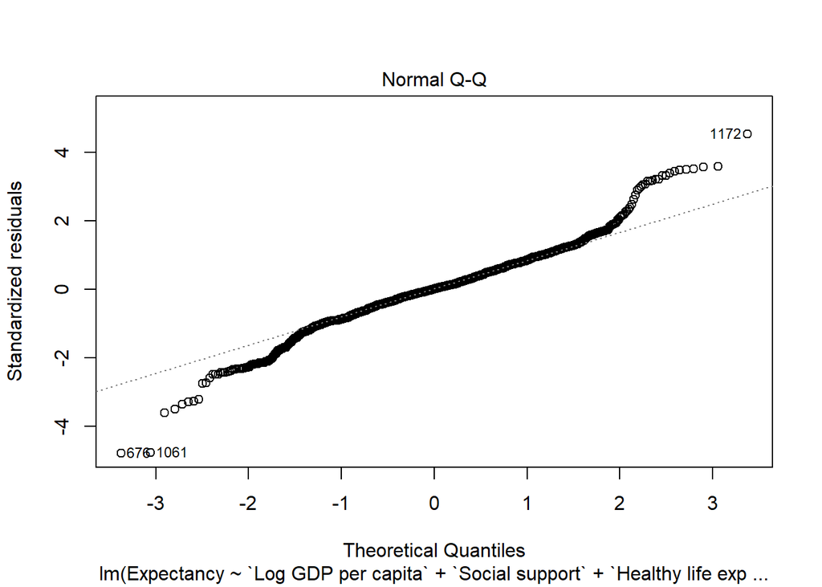

```r
plot(fit_significant, which = 2)
```

Finally, we check the model assumption with QQ plot, and it shows that the normality assumption is valid since the majority of residuals are along with the diagonal.

### Question 2

Question: *What is the relationship between continents and life expectancy?*

Initial Results:

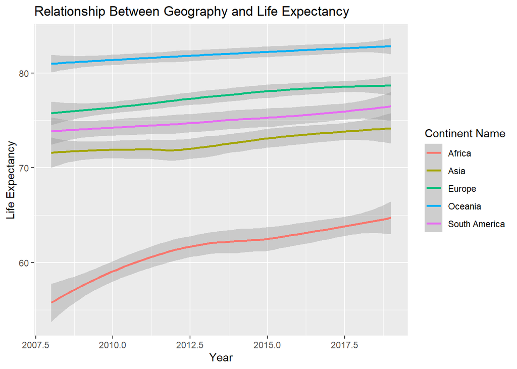

```r
data %>%
  select(Expectancy, Continent_Name, `year`) %>%
  group_by(Continent_Name) %>%
  ggplot(aes(year, Expectancy ,color = Continent_Name)) +
  geom_smooth() +
  ggtitle("Relationship Between Geography and Life Expectancy") +
  labs(color = "Continent Name") +
  xlab("Year") +
  ylab("Life Expectancy")
```

### Question 3

Question: *what is the relationship between continents and happiness?*

Initial Results:

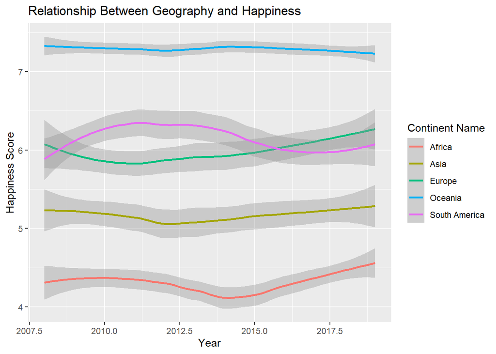

```r
data %>%
  select(year, `Life Ladder`, Continent_Name) %>%
  group_by(`Continent_Name`) %>%
  ggplot(aes(year, `Life Ladder` ,color = Continent_Name)) + geom_smooth() +
  ggtitle("Relationship Between Geography and Happiness") +
  labs(color = "Continent Name") +
  xlab("Year") +
  ylab("Happiness Score")
```

### Question 4

Question: *Do happy people live longer? if so which variable affects both life expectancy and world wide happiness the most?*

Initial Results:

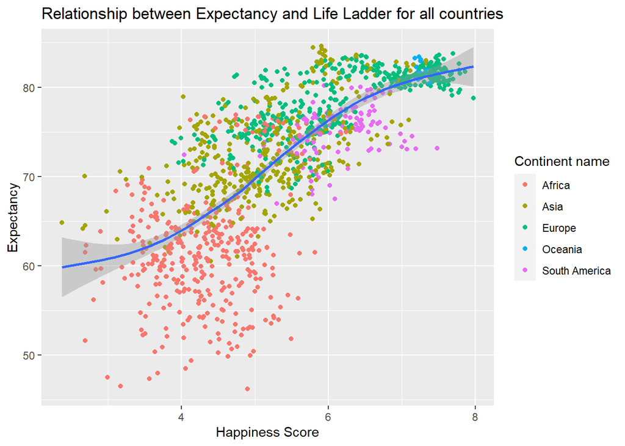

```r
data %>%
  select(Expectancy, `Life Ladder`, Continent_Name) %>%
  ggplot(aes(`Life Ladder`, Expectancy)) +
  geom_point(aes(color = Continent_Name)) +
  geom_smooth() +
  ggtitle("Relationship between Expectancy and Life Ladder for all countries") +
  xlab("Happiness Score") +
  labs(color = "Continent name")
```

```r
mod_expc <- lm(Expectancy~`Log GDP per capita` + `Social support` +
                 `Freedom to make life choices` +`Life Ladder` +
                 `Healthy life expectancy at birth` + `Generosity` +
                 `Perceptions of corruption` + `Positive affect` +
                 `Negative affect`, data = data)
(summary_exp<- tidy(mod_expc)) %>%
  slice(2:11) %>%
  arrange(desc(abs(estimate))) %>%
  select(1,2)
```

```
## # A tibble: 9 x 2
##   term                               estimate
##   <chr>                                 <dbl>
## 1 `Negative affect`                    2.16
## 2 `Social support`                    -1.38
## 3 `Positive affect`                   -1.27
## 4 `Healthy life expectancy at birth`   1.08
## 5 Generosity                           1.06
## 6 `Log GDP per capita`                 0.435
## 7 `Perceptions of corruption`          0.374
## 8 `Life Ladder`                       -0.0965
## 9 `Freedom to make life choices`       0.0866
```

```r
mod_ll <- lm(`Life Ladder` ~ `Expectancy` + `Log GDP per capita` +
               `Social support` + `Freedom to make life choices` +
               `Healthy life expectancy at birth` + `Generosity` +
               `Perceptions of corruption` + `Positive affect` +
               `Negative affect`, data = data)
(summary_ll <- tidy(mod_ll)) %>%
  slice(2:11) %>%
  arrange(desc(abs(estimate))) %>%
  select(1,2)
```

```
## # A tibble: 9 x 2
##   term                               estimate
##   <chr>                                 <dbl>
## 1 `Social support`                     2.04
## 2 `Positive affect`                    1.54
## 3 `Perceptions of corruption`         -0.677
## 4 Generosity                           0.524
## 5 `Freedom to make life choices`       0.431
## 6 `Log GDP per capita`                 0.406
## 7 `Negative affect`                    0.248
## 8 `Healthy life expectancy at birth`   0.0447
## 9 Expectancy                          -0.0198
```

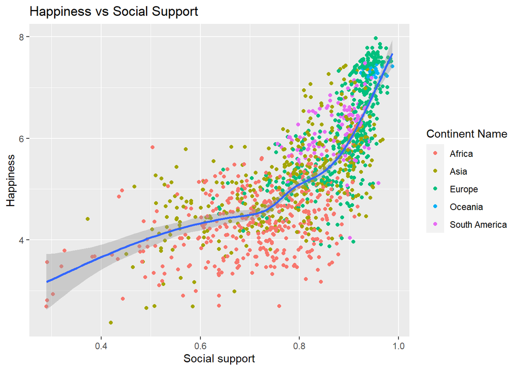

```r
#Life ladder vs social support
data %>%
  select(`Social support`, `Life Ladder`, Continent_Name) %>%
  ggplot(aes(x = `Social support`, y = `Life Ladder`)) +
  geom_point(aes(color = Continent_Name)) +
  geom_smooth() +
  ggtitle("Happiness vs Social Support") +
  ylab("Happiness") +
  labs(color = "Continent Name")
```

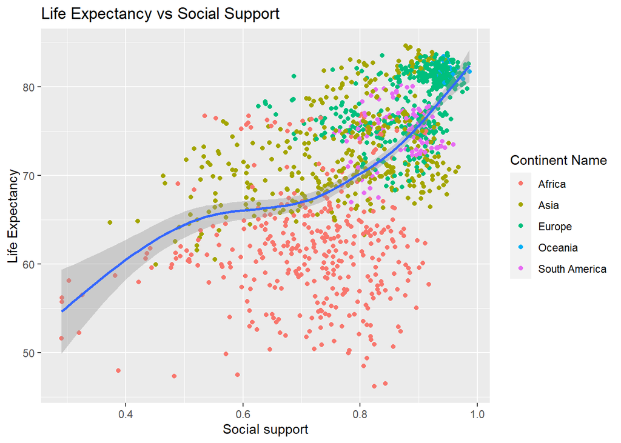

```r
#Expectancy vs social support
data %>%
  select(`Social support`, Expectancy, Continent_Name) %>%
  ggplot(aes(x = `Social support`, y = Expectancy)) +
  geom_point(aes(color = Continent_Name)) +
  geom_smooth() +
  ggtitle("Life Expectancy vs Social Support") +
  ylab("Life Expectancy") +
  labs(color = "Continent Name")
```

Hence, we used ggplot to illustrate the relationships between Social Support against Life Expectancy and Life Ladder Happiness. As seen from the above two plots, higher ranking in Social Support would suggest a higher Life Expectancy and a higher Life Ladder Ranking.

### Question 5

Question: *Does a change in life expectancy reflect a similar change in happiness?*

Initial Results:

```r
fit1 <- lm(Expectancy ~ `Life Ladder`, data = data)
tidy(fit1)
```

```
## # A tibble: 2 x 5
##   term          estimate std.error statistic   p.value
##   <chr>            <dbl>     <dbl>     <dbl>     <dbl>
## 1 (Intercept)      43.2      0.750      57.6 0
## 2 `Life Ladder`     5.34     0.137      39.0 2.85e-223
```

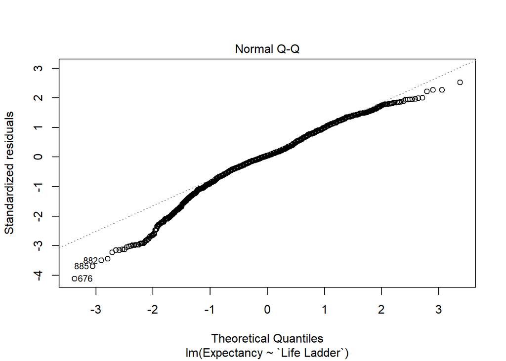

```r
plot(fit1, which = 2)
```

```r
fit2 <- lm(`Life Ladder` ~ Expectancy, data = data)
tidy(fit2)
```

```
## # A tibble: 2 x 5
##   term        estimate std.error statistic   p.value
##   <chr>          <dbl>     <dbl>     <dbl>     <dbl>
## 1 (Intercept)  -1.76     0.184       -9.55 5.79e- 21
## 2 Expectancy    0.0991   0.00254     39.0  2.85e-223
```

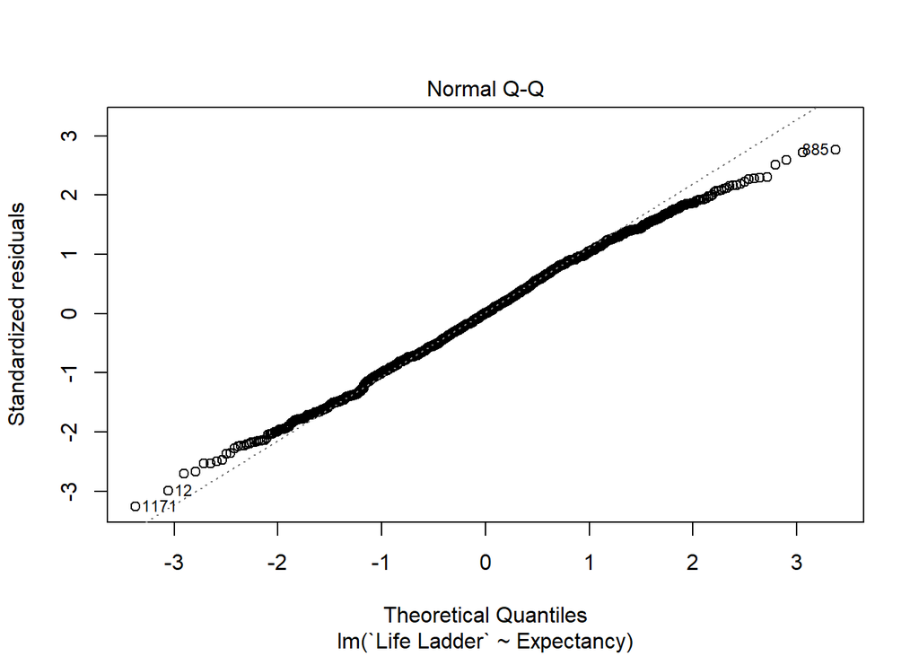

```r
plot(fit2, which = 2)
```

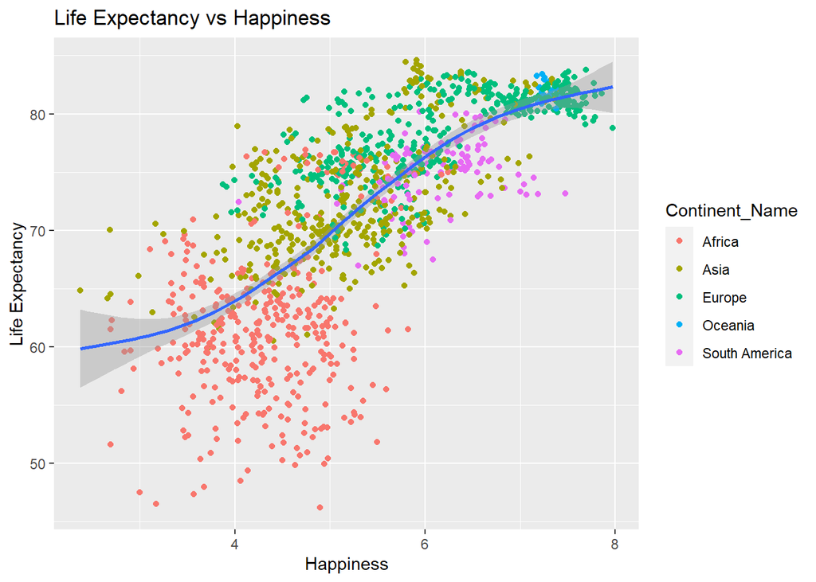

```r
data %>% select(`Life Ladder`, Expectancy, Continent_Name) %>%
  ggplot(aes(x = `Life Ladder`, y = Expectancy)) +
  geom_point(aes(color = Continent_Name)) +
  geom_smooth() +
  ggtitle("Life Expectancy vs Happiness") +
  xlab("Happiness") +
  ylab("Life Expectancy") +
  labs("Continent Name")
```

Here, we demonstrated the plot of Life Ladder Happiness against Expectancy. Comparing with the plot of Expectancy against Life Ladder Happiness in Question 4, we noticed that they both have positive relationship.